# c6w4q1

R. Handsfield

January 14, 2016

# 1.

A pharmaceutical company is interested in testing a potential blood pressure lowering medication. Their first examination considers only subjects that received the medication at baseline then two weeks later. The data are as follows (SBP in mmHg)

| Subject | Baseline | Week 2 |
| --- | --- | --- |
| 1 | 140 | 132 |
| 2 | 138 | 135 |
| 3 | 150 | 151 |
| 4 | 148 | 146 |
| 5 | 135 | 130 |

Consider testing the hypothesis that there was a mean reduction in blood pressure? **Give the P-value for the associated two sided T test.**

(Hint, consider that the observations are paired.)

1. 0.10
2. 0.05
3. **0.087**
4. 0.043

## Solution

There are several ways to do this test

1. Was there a reduction in blood pressure? $~~~ \{H_0: \mu < \mu_0 \}$
2. Was there an increase in blood pressure? $~~~ \{H_0: \mu > \mu_0 \}$
3. Was there any effect from the medication? $~~~ \{H_0: \mu = \mu_0 \}$

The question implies that we should use option 3, because $\mu \neq \mu_0$ requires a two-sided test.

We can calculate the average difference before and after the drug, and it should be greater or less than $\left( 0 \pm random ~ error \right)$ (null hypothesis). There is a small chance that the medication had no effect, but our sample shows a net drop or rise anyway. What is the probability that a $mean_{bp} \neq 0$ truly indicates a population-wide effect?

We interpret this as “For a t-distribution, what is the probability that a very low, or very high value is obtained if the distribution is centered at zero?”

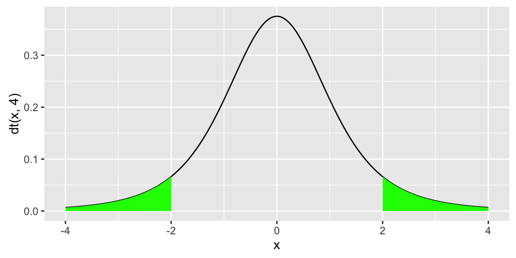

If the test statistic is in either of the extreme regions, we should reject the null hypothesis, and conclude that the drug did have an effect.

Summary:

- $\mu_0 = 0, ~~~~ n = 5, ~~~~ df = n-1$
- $\{H_0: \mu = \mu_0\} ~~~$ $~~~ \{H_a: \mu \neq \mu_0\}$
- $\bar X \equiv average ~ of ~ (week2 ~ - ~ baseline)$
- $Reject ~ H_0 ~ if ~ TS \leq tQ_{lo} ~ or ~ TS \geq tQ_{hi}$
- $\left\{ TS = \frac{\bar X - \mu_0}{SE_\mu} \right\} ~~~$
- $~~~ tQ_{.95; ~ df} = \pm t_{\{.025; ~ 4\}}$

```r
mu0 <- 0;
baseline <- c(140, 138, 150, 148, 135);
week2 <- c(132, 135, 151, 146, 130);
X <- mean(week2 - baseline);
n <- 5;
df <- n-1;
SE <- sd(week2 - baseline)/sqrt(n);

TS <- (X - mu0)/SE;
tQ <- c(-1,1) * qt(.975,df);

TS <- round(TS, 2);
tQ <- round(tQ, 2);
```

```
##      X    TS
## 1 -3.4 -2.26
```

```
##      tQ
## 1 -2.78
## 2  2.78
```

The average blood pressure difference for the group is $-3.4$, which is $2.26$ standard t-units below the distribution mean of $0$. Our two-sided t-quantiles were set so that *if* the population distribution is truly centered at zero (the drug has no effect), then there is less than a 5% chance that a test statistic from any sample would fall outside the domain $\pm 2.78$.

Our test statistic is $-2.26$, which is *not* outside the $\pm 2.78$ domain. So we must conclude that the null hypothesis $\{H_0: \mu = \mu_0\}$ is correct, and from this 5-person sample, we determine that the drug did not have an effect across the broader population.

All the previous work was just the preliminary stuff to understand the question. Now we can calculate the *probability* that a sample mean $\bar X$ would have a value of $\pm 2.26$ standard t-units from the mean of the distribution.

```r
# from above, TS = -2.26; df = 4
pt(-2.26, 4, lower.tail = TRUE) * 2
```

```
## [1] 0.08668046
```

There is an $8.7\%$ probability that a sample mean $\bar X$ of $\pm3.4$ might be produced, *if* the drug had no effect in the broader population $(\mu = 0)$.

In terms of doing the R-calculation, you can do it more efficiently with `stats::t.test()`.

```r
t.test(y=baseline, x=week2, alternative="two.sided", mu=0, paired=TRUE, conf.level=0.025)
```

```
##
##  Paired t-test
##
## data:  week2 and baseline
## t = -2.2616, df = 4, p-value = 0.08652
## alternative hypothesis: true difference in means is not equal to 0
## 2.5 percent confidence interval:
##  -3.450123 -3.349877
## sample estimates:
## mean of the differences
##                    -3.4
```

**Answer: 8.7%**

# 2.

A sample of 9 men yielded a sample average brain volume of 1,100cc and a standard deviation of 30cc. What is the complete set of values of $\mu_0$ that a test of $\{H_0:\mu=\mu_0\}$ would fail to reject the null hypothesis in a two sided 5% Students t-test?

1. **1077 to 1123**
2. 1081 to 1119
3. 1080 to 1120
4. 1031 to 1169

## Solution

In summary, this question supplies $\bar X$ and asks for all values of $\mu_0$ that are within the 95% t-confidence interval. Most questions supply $\mu_0$ and ask for $\bar X$. Both forms are the same damn calculation.

```r
1100 + c(-1,1) * qt(.975,8) * (30/sqrt(9))
```

```
## [1] 1076.94 1123.06
```

The longer derivation and interpretation follow.

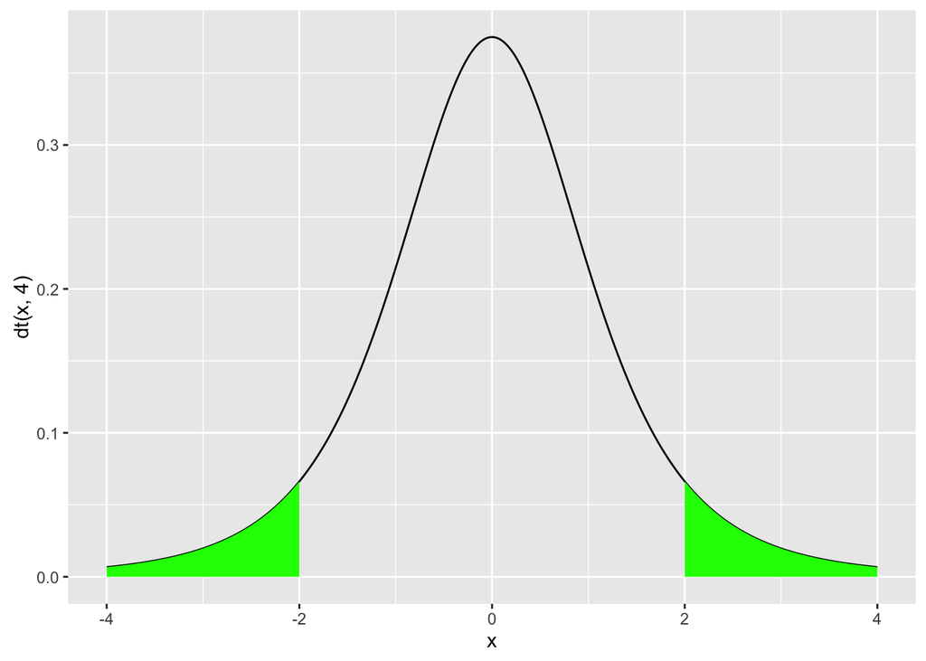

Since the test statistic $TS$ is a function of $\bar X, \mu_0, \sigma,$ and $n$, we can easily solve for $\mu_0$.

$$TS = \frac{\bar X - \mu_0}{SE_\bar X} ~ \therefore ~ \mu_0 = \bar X - SE_\bar X * TS$$

The domain for which we fail to reject $H_0$ is
$$tQ_{lo} < TS < tQ_{hi} ~~~ \to ~~~ tQ_{lo} < \frac{\bar X - \mu_0}{SE_\bar X} < tQ_{hi}$$

$$\therefore ~~~~ \mu_0 \in
\left\{\begin{matrix}
\mathbb{R} > ( \bar X - tQ_{hi} * SE_\bar X )\\
\mathbb{R} < ( \bar X - tQ_{lo} * SE_\bar X )
\end{matrix}\right.$$

Additionally, because the t-distribution is symetric, and $tQ_{lo} = -tQ_{hi}$ we can simplify the problem, and find the entire domain of $\mu_0$ in terms of $tQ_{hi}$:
$$\mu_0 \in
\left\{\begin{matrix}
\mathbb{R} > ( \bar X - tQ_{hi} * SE_\bar X )\\
\mathbb{R} < ( \bar X + tQ_{hi} * SE_\bar X )
\end{matrix}\right.$$

$$( \bar X - tQ_{hi} * SE_\bar X ) < \mu_0 < ( \bar X + tQ_{hi} * SE_\bar X )$$

The interpretation of this is “If the population is centered anywhere in $\bar X \pm tQ * SE_\bar X$, then a given sample mean $~ \bar X$ suggests that $\{H_0:\mu=\mu_0\}$ should not be rejected.”

Summary:

- $\bar X = 1100, ~~~~ \sigma = 30, ~~~~ n = 9, ~~~~ df = (n-1) ~~~~, SE_\bar X = \frac{\sigma}{\sqrt n}$
- $\{H_0:\mu=\mu_0\}, ~~~~ \{H_a:\mu \neq \mu_0\}$
- $TS = \frac{\bar X - \mu_0}{SE_\mu}$
- $SE_\bar X = \frac{\sigma_\mu}{\sqrt n}$
- $tQ_{hi} = t_{\{ 1 - \frac{\alpha}{2}; ~ df \}} = t_{\{.975; ~ 8\}}$

```r
X <- 1100
n <- 9
sigma <- 30
SE <- sigma / sqrt(n)

X + c(-1, 1) * qt(.975,8) * SE
```

```
## [1] 1076.94 1123.06
```

**Answer: 1077 to 1123**

# 3.

Researchers conducted a blind taste test of Coke versus Pepsi. Each of four people was asked which of two blinded drinks given in random order that they preferred. The data was such that 3 of the 4 people chose Coke. Assuming that this sample is representative, report a P-value for a test of the hypothesis that Coke is preferred to Pepsi using a one sided exact test.

1. 0.10
2. 0.005
3. 0.62
4. **0.31**

## Solution

Coke vs Pepsi is a binomial system. “Coke” = Success, or $1$.

What is the probability that $\{3 Coke, 1 Pepsi\}$ was drawn from a sample in which the true Coke preference is greater than 0.5?

- $H_0: P(Coke) = 0.5$
- $H_a: P(Coke) > 0.5$

The parameter `alternative` determines whether $H_a$ is $'>', '<', or '\neq'$.

```r
binom.test(x = c(3,1), p = 0.5, alternative="greater", conf.level = .95)$p.value
```

```
## [1] 0.3125
```

```r
pbinom(2, size = 4, prob = 0.5, lower.tail = FALSE)
```

```
## [1] 0.3125
```

```r
choose(4, 3) * 0.5^4 + choose(4, 4) * 0.5^4
```

```
## [1] 0.3125
```

There is only a 31% probability that {3 Coke, 1 Pepsi} is drawn from a population in which $P(Coke) = 0.5$

**Answer: $31 \%$**

# 4.

Infection rates at a hospital above 1 infection per 100 person days at risk are believed to be too high and are used as a benchmark. A hospital that had previously been above the benchmark recently had 10 infections over the last 1,787 person days at risk. About what is the one sided P-value for the relevant test of whether the hospital is *below* the standard?

1. 0.52
2. 0.22
3. **0.03**
4. 0.11

## Solution

Rates of infection can be modeled by the Poisson distribution

Infection benchmark = 0.01 infection per person-day  
Infection value = 0.005596 infection per person-day

- $H_0: rate_I = 0.01$
- $H_a: rate_I < 0.01$

If the benchmark rate is 0.01, what is the probability of a hospital having such a low actual rate (.0056)?

```r
poisson.test(x=10, T=1787, r=.01, alternative = "less")$p.value
```

```
## [1] 0.03237153
```

```r
ppois(10, lambda = 0.01 * 1787)
```

```
## [1] 0.03237153
```

There is only a 3% chance that the hospital’s low infection sample is an outlying sample from a Poisson distribution with the benchmark infection rate $.01$. This hospital has probably done something to truly reduce their infection rate.

**Answer: 0.03**

# 5.

Suppose that 18 obese subjects were randomized, 9 each, to a new diet pill and a placebo. Subjects’ body mass indices (BMIs) were measured at a baseline and again after having received the treatment or placebo for four weeks. The average difference from follow-up to the baseline (followup - baseline) was −3 kg/m2 for the treated group and 1 kg/m2 for the placebo group. The corresponding standard deviations of the differences was 1.5 kg/m2 for the treatment group and 1.8 kg/m2 for the placebo group. **Does the change in BMI appear to differ between the treated and placebo groups?** Assuming normality of the underlying data and a common population variance, **give a p-value** for a two sided t test.

1. Less than 0.05, but larger than 0.01
2. Less than 0.10 but larger than 0.05
3. Larger than 0.10
4. **Less than 0.01**

## Solution

We need to do a two-sample t-test.

```r
n1 <- n2 <- 9
x1 <- -3 ##treated
x2 <- 1 ##placebo
s1 <- 1.5 ##treated
s2 <- 1.8 ##placebo
df1 <- df2 <- 8
dof <- 16

Sp <- sqrt( 8*(s1^2 + s2^2) /16 )
SE <- Sp * sqrt(2/9)
TS <- (x1 - x2) / SE
P <- pt(TS, dof) * 2  # b/c two-sided, pt is half the probability

Sp <- signif(Sp, 3);  SE <- signif(SE, 3);  TS <- signif(TS, 3);  P <- signif(P, 3);

data.frame(Sp, SE, TS, P)
```

```
##     Sp    SE    TS        P
## 1 1.66 0.781 -5.12 0.000103
```

That’s a tiny probability.

**Answer: 0.0001**

# 6.

Brain volumes for 9 men yielded a 90% confidence interval of 1,077 cc to 1,123 cc. Would you reject in a two sided 5% hypothesis test of H0:μ=1,078?

1. **No you wouldn’t reject.**
2. It’s impossible to tell.
3. Where does Brian come up with these questions?
4. Yes you would reject.

## Solution

The higher % confidence interval is always wider, so by definition, the *fail-to-reject* region in a 5% two-sided test includes the 90% interval. A value inside the 90% interval is definitley inside the 95% *fail-to-reject* region.

**Answer: Don’t Reject**

# 7.

Researchers would like to conduct a study of 100 healthy adults to detect a four year mean brain volume loss of .01 mm3. Assume that the standard deviation of four year volume loss in this population is .04 mm3. About what would be the power of the study for a 5% one sided test versus a null hypothesis of no volume loss?

1. **0.80**
2. 0.60
3. 0.70
4. 0.50

## Solution

The difference in before/after subject means they hope(??) to observe is $0.01 mm^3$

- $H_0: mu = 0$
- $H_a: mu > 0$

```r
n <- 100;
d <- .01;
s <- .04;

power.t.test(n=100, delta=.01, sd=.04, type="paired", alternative="one.sided")$power
```

```
## [1] 0.7989855
```

```r
pnorm(1.645 * 0.004, mean = 0.01, sd = 0.004, lower.tail = FALSE)
```

```
## [1] 0.8037244
```

**Answer: 0.80**

# 8.

Researchers would like to conduct a study of n healthy adults to detect a four year mean brain volume loss of .01 mm3. Assume that the standard deviation of four year volume loss in this population is .04 mm3. About what would be the value of n needed for 90% power of type one error rate of 5% one sided test versus a null hypothesis of no volume loss?

1. 120
2. 180
3. 160
4. **140**

## Solution

```r
power.t.test(n=NULL, delta=.01, sd=.04, power=.9, type="paired", alternative="one.sided")$n
```

```
## [1] 138.3856
```

```r
ceiling((4 * (qnorm(0.95) - qnorm(0.1)))^2)
```

```
## [1] 138
```

**Answer: 138.4**

# 9.

As you increase the type one error rate, α, what happens to power?

1. It’s impossible to tell given the information in the problem.
2. **You will get larger power.**
3. You will get smaller power.
4. No, for real, where does Brian come up with these problems?

## Solution

At the extreme high alpha, you reject every $H_0$, which includes rejecting 100% of $H_0$ when $H_a$ is true, 100% power.

**Answer: Larger Power**